# Computational Intelligence - Assignment 1

Bruno Sánchez and Sheena Lang

2024-11-05

## Introduction

This report describes our experiment in training a neural network using back-propagation (BP), genetic algorithms (GA), and evolutionary strategies (ES), and evaluating these methods on the testing dataset. We begin by outlining the data collection process, using synthetic data generation based on the real Iris dataset. Next, we detail each of the three training approaches (BP, GA, and ES) and conduct a hyperparameter search for GA and ES. Finally, we assess the accuracy and training time of these methods under different synthetic data conditions (hardness, noise, and training size) and present a statistical analysis of the results to identify any significant differences.

## Data Collection

We aim to generate synthetic data based on the Iris dataset, a widely used benchmark in machine learning, to maintain a connection to a real-world problem while still allowing for flexibility. By creating synthetic data instead of using the original Iris dataset, we can control the hardness of the classification task and adjust the level of noise, enabling a more flexible experimental setup.

### Iris Dataset Analysis

The Iris dataset consists of flower samples from three different species: Setosa, Versicolor, and Virginica. Each sample includes measurements of four features: sepal length, sepal width, petal length, and petal width. To ensure that our synthetic data accurately simulates Iris samples, we first perform a preliminary analysis to calculate the feature means and covariances for each of the three species.

The following code chunk calculates and displays these statistics:

```r
suppressPackageStartupMessages(library(dplyr))

data <- iris

print(
    data %>%
    group_by(Species) %>%
    summarise(across(where(is.numeric), mean))
)
```

```
## # A tibble: 3 × 5
##   Species    Sepal.Length Sepal.Width Petal.Length Petal.Width
##   <fct>             <dbl>       <dbl>        <dbl>       <dbl>
## 1 setosa             5.01        3.43         1.46       0.246
## 2 versicolor         5.94        2.77         4.26       1.33
## 3 virginica          6.59        2.97         5.55       2.03
```

```r
cov_matrices <- data %>%
    group_by(Species) %>%
    summarise(cov_matrix = list(cov(select(cur_data(), where(is.numeric))))) %>%
    pull(cov_matrix)

names(cov_matrices) <- unique(data$Species)
print(cov_matrices)
```

```
## $setosa
##              Sepal.Length Sepal.Width Petal.Length Petal.Width
## Sepal.Length   0.12424898 0.099216327  0.016355102 0.010330612
## Sepal.Width    0.09921633 0.143689796  0.011697959 0.009297959
## Petal.Length   0.01635510 0.011697959  0.030159184 0.006069388
## Petal.Width    0.01033061 0.009297959  0.006069388 0.011106122
##
## $versicolor
##              Sepal.Length Sepal.Width Petal.Length Petal.Width
## Sepal.Length   0.26643265  0.08518367   0.18289796  0.05577959
## Sepal.Width    0.08518367  0.09846939   0.08265306  0.04120408
## Petal.Length   0.18289796  0.08265306   0.22081633  0.07310204
## Petal.Width    0.05577959  0.04120408   0.07310204  0.03910612
##
## $virginica
##              Sepal.Length Sepal.Width Petal.Length Petal.Width
## Sepal.Length   0.40434286  0.09376327   0.30328980  0.04909388
## Sepal.Width    0.09376327  0.10400408   0.07137959  0.04762857
## Petal.Length   0.30328980  0.07137959   0.30458776  0.04882449
## Petal.Width    0.04909388  0.04762857   0.04882449  0.07543265
```

### Synthetic Data Generation

By using the means and covariances of the three flower species, we generate synthetic samples by drawing data points from distributions defined by these statistical properties.

To introduce flexibility, we add parameters to control two aspects: *hardness* and *noise* of the data.

- *Hardness* controls the separation between species, with higher values making the classification task easier. Increasing hardness involves expanding the distance between the species’ feature distributions, making them more distinct and easier to classify.
- *Noise* adds random variation to the data, making the classification task more challenging. A higher noise parameter increases overlap between the species’ distributions by introducing variability to feature values. This reduces the distinctiveness of the species and makes it harder for the model to classify them correctly.

These parameters allow us to simulate a range of classification challenges, from well-separated species with minimal noise (easy classification) to highly overlapping distributions with high noise (difficult classification).

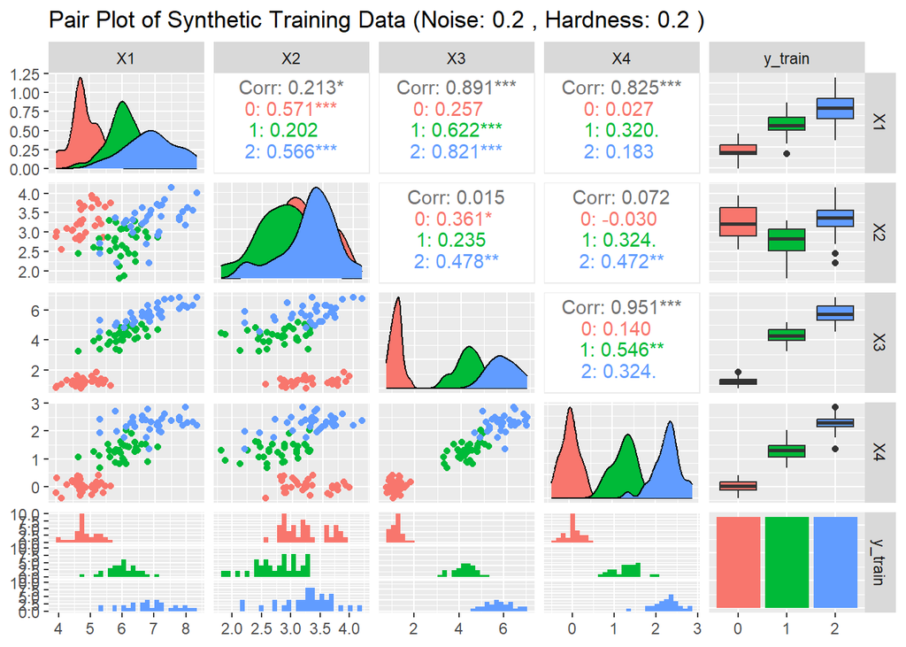

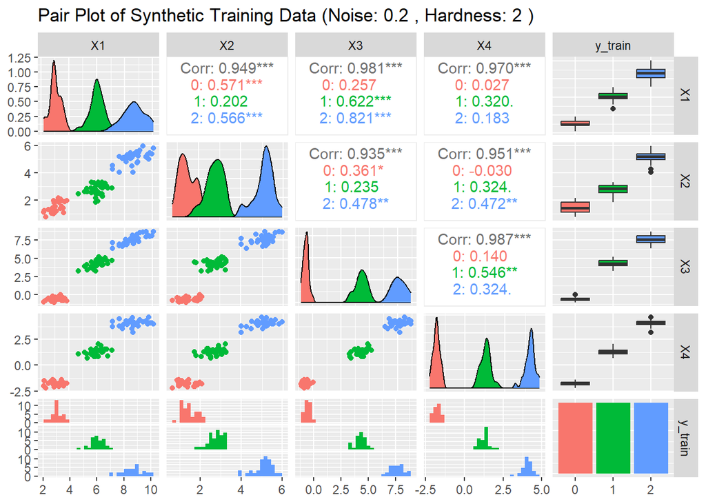

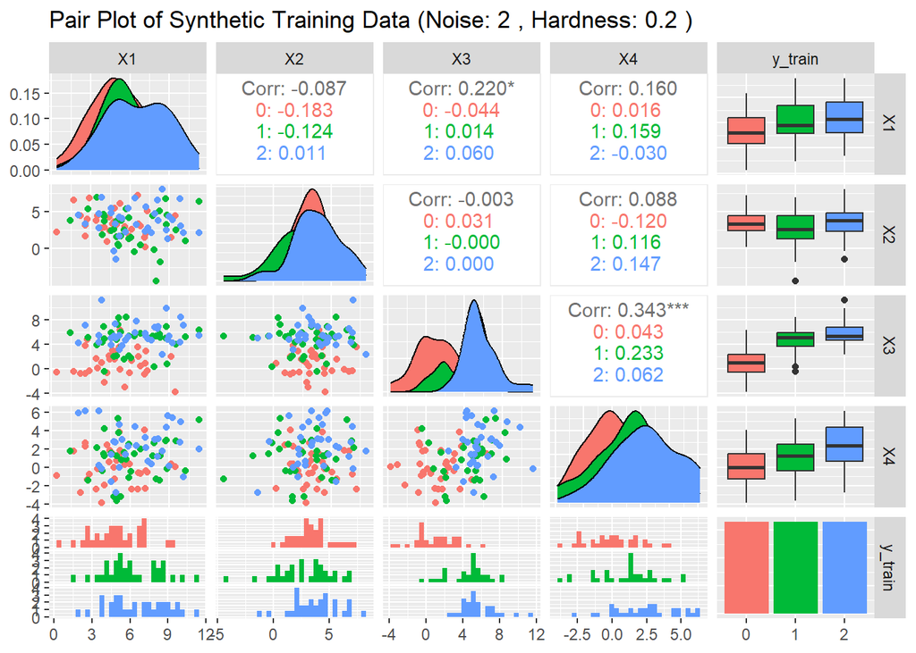

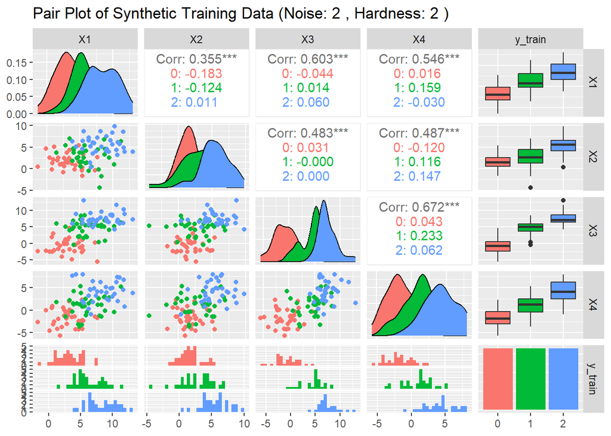

```r
suppressPackageStartupMessages(library(MASS))
suppressPackageStartupMessages(library(caret))
suppressPackageStartupMessages(library(lattice))
suppressPackageStartupMessages(library(GGally))


generate_synthetic_data <- function(n_train, n_val, n_test, noise_level = 0.1, hardness = 0.5) {
  set.seed(123)

  mu_setosa <- c(5.01, 3.43, 1.46, 0.246)
  mu_versicolor <- c(5.94, 2.77, 4.26, 1.33)
  mu_virginica <- c(6.59, 2.97, 5.55, 2.03)

  mu_setosa <- mu_setosa - c(hardness, hardness, hardness, hardness)
  mu_virginica <- mu_virginica + c(hardness, hardness, hardness, hardness)

  setosa_cov <- matrix(c(
    0.12424898, 0.099216327, 0.016355102, 0.010330612,
    0.09921633, 0.143689796, 0.011697959, 0.009297959,
    0.01635510, 0.011697959, 0.030159184, 0.006069388,
    0.01033061, 0.009297959, 0.006069388, 0.011106122
  ), nrow = 4, byrow = TRUE)

  versicolor_cov <- matrix(c(
    0.26643265, 0.08518367, 0.18289796, 0.05577959,
    0.08518367, 0.09846939, 0.08265306, 0.04120408,
    0.18289796, 0.08265306, 0.22081633, 0.07310204,
    0.05577959, 0.04120408, 0.07310204, 0.03910612
  ), nrow = 4, byrow = TRUE)

  virginica_cov <- matrix(c(
    0.40434286, 0.09376327, 0.30328980, 0.04909388,
    0.09376327, 0.10400408, 0.07137959, 0.04762857,
    0.30328980, 0.07137959, 0.30458776, 0.04882449,
    0.04909388, 0.04762857, 0.04882449, 0.07543265
  ), nrow = 4, byrow = TRUE)

  X_setosa_train <- mvrnorm(n_train %/% 3, mu_setosa, setosa_cov)
  X_setosa_val <- mvrnorm(n_val %/% 3, mu_setosa, setosa_cov)
  X_setosa_test <- mvrnorm(n_test %/% 3, mu_setosa, setosa_cov)

  X_versicolor_train <- mvrnorm(n_train %/% 3, mu_versicolor, versicolor_cov)
  X_versicolor_val <- mvrnorm(n_val %/% 3, mu_versicolor, versicolor_cov)
  X_versicolor_test <- mvrnorm(n_test %/% 3, mu_versicolor, versicolor_cov)

  X_virginica_train <- mvrnorm(n_train %/% 3, mu_virginica, virginica_cov)
  X_virginica_val <- mvrnorm(n_val %/% 3, mu_virginica, virginica_cov)
  X_virginica_test <- mvrnorm(n_test %/% 3, mu_virginica, virginica_cov)

  X_train <- rbind(X_setosa_train, X_versicolor_train, X_virginica_train)
  y_train <- c(rep(0, n_train %/% 3), rep(1, n_train %/% 3), rep(2, n_train %/% 3))

  X_val <- rbind(X_setosa_val, X_versicolor_val, X_virginica_val)
  y_val <- c(rep(0, n_val %/% 3), rep(1, n_val %/% 3), rep(2, n_val %/% 3))

  X_test <- rbind(X_setosa_test, X_versicolor_test, X_virginica_test)
  y_test <- c(rep(0, n_test %/% 3), rep(1, n_test %/% 3), rep(2, n_test %/% 3))

  X_train <- X_train + rnorm(length(X_train), 0, noise_level)
  X_val <- X_val + rnorm(length(X_val), 0, noise_level)
  X_test <- X_test + rnorm(length(X_test), 0, noise_level)

  list(
    train = data.frame(X_train, y_train = as.factor(y_train)),
    val = data.frame(X_val, y_val = as.factor(y_val)),
    test = data.frame(X_test, y_test = as.factor(y_test))
  )
}

# ---------- DATA PARAMETERS ----------

hardness_values <- c(0.2, 2)
noise_levels <- c(0.2, 2)
training_sizes <- c(100)
validation_size <- 1000
test_size <- 1000

# Plotting the data distributions for each of the hardness and noise values

for (training_size in training_sizes){
    for (noise_level in noise_levels) {
        for (hardness in hardness_values) {
            synthetic_data <- generate_synthetic_data(training_size, validation_size, test_size, noise_level, hardness)
            plot <-ggpairs(synthetic_data$train, aes(color = y_train)) +
            ggtitle(paste("Pair Plot of Synthetic Training Data (Noise:", noise_level, ", Hardness:", hardness, ")"))
            print(plot)
        }
    }
}
```

## Neural Network

In this section, we utilize the *nnet* package to implement a training function that utilizes BP for our neural network by fitting a model to the training data, specifying parameters such as the number of units in the hidden layer and decay rate. Additionally, we define a test function to evaluate our neural network on the testing data, assessing its predictive accuracy. This testing function is employed not only for evaluating the training using BP, as defined here, but also for assessing models trained with GAs and ESs.

```r
suppressPackageStartupMessages(library(nnet))

train_bp <- function(train_data, size, maxit, specific_params) {
  decay <- specific_params$decay
  train_data$y_train <- as.factor(train_data$y_train)

  model <- nnet(y_train ~ .,
    data = train_data,
    size = size,
    maxit = maxit,
    decay = decay,
    linout = FALSE,
    trace = FALSE
  )

  return(model)
}

test <- function(model, test_data) {
  y_pred <- predict(model, newdata = test_data[, -ncol(test_data)], type = "class")

  accuracy <- accuracy <- mean(y_pred == test_data[, ncol(test_data)])

  return(accuracy)
}
```

## Genetic Algorithm

In this section, we set up the iterative process of training a neural network using a GA instead of BP, through the use of the *GA* library. In order to do this, we iteratively evaluate candidate neural networks (out of a population) according to their classification performance on the training data. Additionally, we include the number of neurons of the neural network as an evolvable parameter, limited by a maximum size (for which we will later evaluate different values).

The training process of the Neural Network with the GA is as follows:

1. Generate a population where each individual has a random number of neurons (an integer between 1 and the maximum size) and a random sets of weights (each a real number between -1 and 1).
2. For each individual of the population, build a neural network with the corresponding number of neurons and set of weights. This is a candidate neural network.
3. With each candidate neural network, make predictions on the training set and, since GAs maximize the fitness function, return the opposite of the misclassification error as its fitness score.
4. Once the GA is finished, extract the individual with the best fitness and return the neural network associated with it.

This process is implemented in the following code:

```r
suppressPackageStartupMessages(library(GA))


train_ga <- function(train_data, size, maxit, specific_params) {
  pcrossover <- specific_params$pcrossover
  pmutation <- specific_params$pmutation
  popSize <- specific_params$pop_size_ga

  min_size <- 1
  max_size <- size

  n_params <- 5 * max_size + (max_size + 1) * 3

  # Set lower and upper bounds for the weights
  lower <- c(min_size, rep(-1, n_params))
  upper <- c(max_size, rep(1, n_params))

  # Set up GA parameters with filled lower and upper bounds
  ga_model <- ga(
    type = "real-valued",
    fitness = fitness_function,
    lower = lower,
    upper = upper,
    pcrossover = pcrossover,
    pmutation = pmutation,
    popSize = popSize,
    maxiter = maxit,
    run = 50,
    monitor = FALSE
  )

  # Retrieve optimized weights
  # Returns all of the individuals that are tied for the best fitness score, we only keep the first
  optimal_weights <- ga_model@solution[1, ]

  optimal_size <- round(optimal_weights[1])
  nn_model <- nnet(
    y_train ~ .,
    data = train_data,
    size = optimal_size,
    linout = FALSE,
    maxit = 0,
    decay = 0,
    trace = FALSE
  )

  optimal_n_params <- 5 * optimal_size + (optimal_size + 1) * 3

  # Set weights of the neural network
  nn_model$wts <- optimal_weights[2:(optimal_n_params + 1)]

  return(nn_model)
}


fitness_function <- function(weights) {
  # Instantiate the neural network with the number of neurons given by the first gene
  size <- round(weights[1])
  nn_model <- nnet(
    y_train ~ .,
    data = train_data,
    size = size,
    linout = FALSE,
    maxit = 0,
    decay = 0,
    trace = FALSE
  )

  # Set weights of the neural network
  nn_model$wts <- weights[-1]

  # Predict on training data
  predictions <- predict(nn_model, as.matrix(train_data[, -ncol(train_data)]), type = "class")

  # Calculate misclassification error
  error <- mean(predictions != train_data[, ncol(train_data)])

  # Return negative error to maximize fitness function
  return(-error)
}
```

## Hyperparameter Search GA

The GA training function employs three key parameters: **p-crossover**, which represents the probability of combining genes from two parent solutions to create offspring; **p-mutation**, which indicates the likelihood of introducing random changes to a solution to maintain genetic diversity; and **popsize**, which defines the total number of candidate solutions in each generation.

Since we are modifying parameters of the data such as noise, hardness, and training size, we decided to keep the GA parameters constant. To establish these constant parameters, we conducted a small hyperparameter search using a training size of 200, a hardness of 0.5, and a noise of 0.5. We will vary these values in our evaluation, but for simplicity, we chose these parameters as they represent a middle ground within the ranges we will assess later. By running the code chunk below, we identified the optimal parameters: a crossover probability of 0.7, a mutation probability of 0.2, and a population size of 100.

```r
hyperparam_search_ga <- function(train_data, validation_data, pcrossover_values, pmutation_values, popSize_values) {
  print("Running hyperparameter search ga...")

  best_model <- NULL
  best_score <- -Inf
  best_params <- list()

  for (pcrossover in pcrossover_values) {
    for (pmutation in pmutation_values) {
      for (popSize in popSize_values) {
        specific_params <- list(pcrossover = pcrossover, pmutation = pmutation, pop_size_ga = popSize)

        model <- train_ga(train_data, size, maxit, specific_params)

        score <- test(model, validation_data)

        if (score > best_score) {
          best_score <- score
          best_model <- model
          best_params <- list(pcrossover = pcrossover, pmutation = pmutation, popSize = popSize)
        }

        cat("Tested pcrossover =", pcrossover, "pmutation =", pmutation, "popSize =", popSize, "-> score:", score, "\n")
      }
    }
  }
  best_p_crossover_ga <- best_params$pcrossover
  best_p_mutation_ga <- best_params$pmutation
  best_pop_size_ga <- best_params$popSize


  cat("Best pcrossover:", best_p_crossover_ga, "Best pmutation:", best_p_mutation_ga, "Best popsize:", best_pop_size_ga, "Best score:", best_score, "\n")

  return(list(best_model = best_model, best_score = best_score, best_params = best_params))
}

data <- generate_synthetic_data(200, 200, 200, 0.5, 0.5)
train_data <- data$train
validation_data <- data$val

size <- 10
maxit <- 200

# Define possible hyperparameter ranges
pcrossover_values <- c(0.7, 0.8, 0.9)
pmutation_values <- c(0.05, 0.1, 0.2)
popSize_values <- c(20, 50, 100)

best_result <- hyperparam_search_ga(train_data, validation_data, pcrossover_values, pmutation_values, popSize_values)

best_pcrossover_ga <- best_result$best_params$pcrossover
best_pmutation_ga <- best_result$best_params$pmutation
best_pop_size_ga <- best_result$best_params$popSize
```

[output not shown]

## Evolution Strategy

In this section, we set up the iterative process of training a neural network using an ES instead of BP, employing the *cmaesr* library. This process is essentially the same as the one we perform with the GA, with some key changes:

- We employ an ES instead of a GA for the evolution of the population. In addition to adapting the candidate neural networks, an ES also evolves the mutation parameters themselves separately for each individual.
- An ES minimizes the objective function, so we utilize the opposite of the previous GA fitness function as objective (i.e. the misclassification error).

```r
suppressPackageStartupMessages(library(cmaesr))

train_es <- function(train_data, size, maxit, specific_params) {
  sigma <- specific_params$sigma
  popSize <- specific_params$pop_size_es
  min_size <- 1
  max_size <- size

  n_params <- 5 * max_size + (max_size + 1) * 3

  lower <- c(min_size, rep(-1, n_params))
  upper <- c(max_size + 1, rep(1, n_params))

  obj.fn <- makeSingleObjectiveFunction(
    name = "Neural Network Fitness Function",
    fn = function(x) -fitness_function(x), # ES minimizes objective function
    par.set = makeNumericParamSet("weights", len = n_params + 1, lower = lower, upper = upper)
  )

  # Run the ES model
  suppressWarnings(
    es_model <- cmaes(
      obj.fn,
      monitor = makeMonitor(),
      control = list(
        sigma = sigma, # initial step size
        lambda = popSize, # number of offspring
        stop.ons = c(
          list(stopOnMaxIters(maxit)), # stop after maxit iterations
          getDefaultStoppingConditions() # or after default stopping conditions
        )
      )
    )
  )

  # Retrieve optimized weights
  optimal_weights <- es_model$best.param

  optimal_size <- round(optimal_weights[1])

  nn_model <- nnet(
    y_train ~ .,
    data = train_data,
    size = optimal_size,
    linout = FALSE,
    maxit = 0,
    decay = 0,
    trace = FALSE
  )

  optimal_n_params <- 5 * optimal_size + (optimal_size + 1) * 3

  # Set weights of the neural network
  nn_model$wts <- optimal_weights[2:(optimal_n_params + 1)]

  return(nn_model)
}
```

## Hyperparameter Search ES

Similarly to the hyperparameter search conducted for the GA, we also perform a hyperparameter search for ES to identify the optimal values for **sigma**, which represents the standard deviation used to control the mutation step size, and the population size, which defines the number of candidate solutions evaluated in each generation. We utilize the same data configuration as for the GA hyperparameter tuning to ensure consistency. By running the code chunk below, we determined the best **sigma** to be 0.4 and the best population size to be 70.

```r
hyperparam_search_es <- function(train_data, validation_data, sigma_values, popSize_values) {
  best_model <- NULL
  best_score <- -Inf
  best_params <- list()

  for (sigma in sigma_values) {
    for (popSize in popSize_values) {
      specific_params <- list(sigma = sigma, pop_size_es = popSize)
      model <- train_es(train_data, size, maxit, specific_params)

      score <- test(model, validation_data)

      if (score > best_score) {
        best_score <- score
        best_model <- model
        best_params <- list(sigma = sigma, popSize = popSize)
      }

      cat("Tested sigma =", sigma, "popSize =", popSize, "-> score:", score, "\n")
    }
  }

  best_sigma_es <- best_params$sigma
  best_pop_size_es <- best_params$popSize

  cat("Best sigma:", best_sigma_es, "Best popSize:", best_pop_size_es, "Best score:", best_score, "\n")

  return(list(best_model = best_model, best_score = best_score, best_params = best_params))
}

data <- generate_synthetic_data(200, 200, 200, 0.5, 0.5)
train_data <- data$train
validation_data <- data$val

size <- 10
maxit <- 200

# Define possible hyperparameter ranges
sigma_values <- c(0.4, 0.5, 0.6)
popSize_values <- c(20, 50, 70)

best_result <- hyperparam_search_es(train_data, validation_data, sigma_values, popSize_values)

best_sigma_es <- best_result$best_params$sigma
best_pop_size_es <- best_result$best_params$popSize
```

[output not shown]

## Experimental Setup

In the experimental setup, we specify various data configurations, namely, hardness, noise, and training sizes. Additionally we vary numbers of hidden neurons (sizes). For each training approach (BP, GA and ES), we evaluate performance by tracking both training times and testing accuracies.

```r
suppressPackageStartupMessages(library(tictoc))

# ---------- DATA PARAMETERS ----------

hardness_values <- c(0.2, 2)
noise_levels <- c(0.2, 2)
training_sizes <- c(100, 500)
validation_size <- 1000
test_size <- 1000

# ---------- RUN PARAMETERS ----------

sizes <- c(1, 10, 20)
maxit <- 200
training_functions <- c("train_bp", "train_ga", "train_es")
specific_params <- list(decay = 0.001, pcrossover = best_pcrossover_ga, pmutation = best_pmutation_ga, pop_size_ga = best_pop_size_ga, sigma = best_sigma_es, pop_size_es = best_pop_size_es)


# ---------- RESULT STRUCTURE ----------

results <- data.frame(
  hardness = numeric(),
  noise = numeric(),
  training_size = numeric(),
  size = numeric(),
  maxit = numeric(),
  training_function = character(),
  test_accuracy = numeric(),
  training_time = numeric(),
  stringsAsFactors = FALSE
)

# ---------- EVALUATION ----------

for (hardness in hardness_values) {
  for (noise in noise_levels) {
    for (training_size in training_sizes) {
      data <- generate_synthetic_data(training_size, validation_size, test_size, noise, hardness)

      train_data <- data$train
      val_data <- data$val
      test_data <- data$test

      for (size in sizes) {
        for (training_function in training_functions) {
          # Retrieve the training function by name
          func <- get(training_function)

          # Measure training time using tic and toc
          tic()
          model <- func(train_data = train_data, size = size, maxit = maxit, specific_params = specific_params)
          training_time <- toc(quiet = TRUE)$toc

          # Test accuracy
          test_accuracy <- test(model, test_data)

          # Store result
          results <- rbind(results, data.frame(
            hardness = hardness,
            noise = noise,
            training_size = training_size,
            size = size,
            training_function = training_function,
            test_accuracy = test_accuracy,
            training_time = training_time
          ))
        }
      }
    }
  }
}

write.csv(results, "results.csv", row.names = FALSE)
```

## Results

In this section, we observe and analyze the results attained in the previous experiment.

### Results Overview

We first perform a preliminary observation of the results. We extract the fastest run per training size, and the most accurate run per hardness and noise values.

```r
results <- read.csv("results.csv")

# Fastest run per training size
fastest_runs <- results %>%
  group_by(training_size) %>%
  filter(training_time == min(training_time)) %>%
  ungroup()

# Most accurate run per hardness and noise
most_accurate_runs <- results %>%
  group_by(hardness, noise) %>%
  filter(test_accuracy == max(test_accuracy)) %>%
  ungroup()

# Fastest Runs per Training Size:
print(fastest_runs, n = Inf, width = Inf)
```

```
## # A tibble: 2 × 7
##   hardness noise training_size  size training_function test_accuracy
##      <dbl> <dbl>         <int> <int> <chr>                     <dbl>
## 1      0.2   0.2           100     1 train_bp                  0.973
## 2      0.2   0.2           500     1 train_bp                  0.249
##   training_time
##           <dbl>
## 1          21.3
## 2         133.
```

```r
# Most Accurate Runs per Hardness and Noise:
print(most_accurate_runs, n = Inf, width = Inf)
```

```
## # A tibble: 9 × 7
##   hardness noise training_size  size training_function test_accuracy
##      <dbl> <dbl>         <int> <int> <chr>                     <dbl>
## 1      0.2   0.2           500     1 train_es                  0.974
## 2      0.2   2             100     1 train_bp                  0.652
## 3      2     0.2           100     1 train_bp                  1
## 4      2     0.2           100    10 train_bp                  1
## 5      2     0.2           100    20 train_bp                  1
## 6      2     0.2           500     1 train_bp                  1
## 7      2     0.2           500    10 train_es                  1
## 8      2     0.2           500    20 train_es                  1
## 9      2     2             500     1 train_bp                  0.899
##   training_time
##           <dbl>
## 1          168.
## 2          290.
## 3          543.
## 4          570.
## 5          620.
## 6          665.
## 7          757.
## 8          838.
## 9          956.
```

First, we see that the BP method seems to achieve the best training times for both training sizes; with an expected significant increase in time between the 2 sets.

Then, we observe that:

- For the data that most resembles the original Iris dataset (low hardness and noise values), the ES achieves the best accuracy score (0.974).
- For the hardest dataset configuration (low hardness and high noise), the highest accuracy score (0.652) is very moderate, and achieved by BP.
- For the easiest configuration (high hardness, low noise), several models achieve a perfect accuracy score of 1, since the data is easily separable.
- For the final configuration (high hardness and noise), the BP again gets the best score (0.899), with only 1 neuron.

### Statistical Analysis

Let us now perform an statistical analysis on the results obtained for the different training methods. The goal of this analysis is to find statistically significant differences among the accuracy scores and times of the 3 training methods.

*Remark:* The code for the statistical analysis is hidden in the final report, but can be visualized in the attached Rmarkdown file. This code was generated by the Claude 3.5 Sonnet LLM model (Anthropic AI, 2024).

```r
# Run the statistical analysis with alpha = 0.15
alpha <- 0.15
analyze_and_report(alpha)
```

```
## Statistical Analysis Report for Training Functions
## ==============================================
##
## Using significance level (alpha) = 0.150
##
##
##
## Analysis of test_accuracy
## ======================
##
## Checking Statistical Assumptions for test_accuracy
## ----------------------------------------
##
## Performing Shapiro-Wilk test for normality:
## H0: Data is normally distributed
## H1: Data is not normally distributed
##
## # A tibble: 3 × 3
##   training_function shapiro_stat shapiro_p
##   <fct>                    <dbl>     <dbl>
## 1 train_bp                 0.831   0.00100
## 2 train_es                 0.847   0.00195
## 3 train_ga                 0.960   0.433
##
## Normality Test Interpretation:
## - train_bp: Not normally distributed (p = 0.0010)
## - train_es: Not normally distributed (p = 0.0019)
## - train_ga: Normally distributed (p = 0.4329)
##
## Performing Levene's test for homogeneity of variance:
## H0: Variances are equal across groups
## H1: Variances are not equal across groups
##
## Levene's Test for Homogeneity of Variance (center = median)
##       Df F value Pr(>F)
## group  2  0.5115 0.6019
##       69
##
## Variance Test Interpretation: Equal variances across groups (p = 0.6019)
##
## Based on these results, non-parametric tests will be used.
##
## Performing Kruskal-Wallis test:
## H0: All groups have the same distribution
## H1: At least one group has a different distribution
##
##
##  Kruskal-Wallis rank sum test
##
## data:  test_accuracy by training_function
## Kruskal-Wallis chi-squared = 5.5998, df = 2, p-value = 0.06082
##
##
## Kruskal-Wallis Test Interpretation: There are significant differences between groups (p = 0.0608)
##
## Performing Dunn's test for pairwise comparisons:
## H0: No difference between the pair of groups
## H1: Significant difference exists between the pair of groups
```

```
##            Comparison           Z    P.unadj      P.adj
## 1 train_bp - train_es 0.006900156 0.99449452 0.99449452
## 2 train_bp - train_ga 2.052796351 0.04009233 0.12027700
## 3 train_es - train_ga 2.045896195 0.04076658 0.06114988
```

```
##
## Dunn's Test Interpretation:
## -------------------------
## - train_es vs train_ga: Significant difference (p = 0.0611)
##   train_es (0.841) performed better than train_ga (0.744)
## - train_bp vs train_ga: Significant difference (p = 0.1203)
##   train_bp (0.821) performed better than train_ga (0.744)
## - train_bp vs train_es: No significant difference (p = 0.9945)
##   train_es (0.841) performed better than train_bp (0.821)
##
## Summary: Found significant differences in 2 out of 3 comparisons.
##
##
## Analysis of training_time
## ======================
##
## Checking Statistical Assumptions for training_time
## ----------------------------------------
##
## Performing Shapiro-Wilk test for normality:
## H0: Data is normally distributed
## H1: Data is not normally distributed
##
## # A tibble: 3 × 3
##   training_function shapiro_stat shapiro_p
##   <fct>                    <dbl>     <dbl>
## 1 train_bp                 0.962     0.470
## 2 train_es                 0.963     0.502
## 3 train_ga                 0.962     0.489
##
## Normality Test Interpretation:
## - train_bp: Normally distributed (p = 0.4701)
## - train_es: Normally distributed (p = 0.5023)
## - train_ga: Normally distributed (p = 0.4889)
##
## Performing Levene's test for homogeneity of variance:
## H0: Variances are equal across groups
## H1: Variances are not equal across groups
##
## Levene's Test for Homogeneity of Variance (center = median)
```

[output cut: 21 more lines]

```
## # A tibble: 3 × 6
##   training_function     n mean_accuracy sd_accuracy mean_time sd_time
##   <fct>             <int>         <dbl>       <dbl>     <dbl>   <dbl>
## 1 train_bp             24         0.821       0.205      524.    330.
## 2 train_es             24         0.841       0.155      571.    337.
## 3 train_ga             24         0.744       0.146      539.    333.
##
##
## Average Test Accuracy:
## - Best performing method: train_es (0.841)
## - Worst performing method: train_ga (0.744)
##
## Average Training Time:
## - Fastest method: train_bp (523.58)
## - Slowest method: train_es (571.29)
```

For our statistical analysis, we utilize a significance level of alpha=0.15. While using alpha=0.05 is the standard, for exploratory studies it can be appropriate to utilize higher values of alpha to help identify potential trends.

Based on this level of significance, we can conclude from these results that the GA training method performs significantly worse in accuracy than both BP and ES methods. While ES achieved slightly higher accuracy than BP on average, this difference is likely insignificant and could be due to random variation. In terms of training time, no significant differences were found among the different methods.

## Conclusion

This report analyzes the effectiveness of back-propagation, genetic algorithms, and evolutionary strategies in training a neural network using synthetic data derived from the Iris dataset. We explore various configurations of this dataset, considering factors such as training size, hardness, and noise levels. The performance of the neural network is evaluated for each training method across different data configurations, focusing on training time and accuracy.